# Trade Count Regression

Tobi Bosede

December 15, 2016

550.700

```r
library(mgcv)
library(ggplot2)
```

```r
setwd("C:/Users/aniverb/Documents/Grad_School/JHU/700")
trade_data=read.table("trades_count_regression_2016-11-18.txt", header=T)
trade_data=trade_data[order(trade_data$Date),]
head(trade_data)
```

```
##     ProductName   Maturity       Date TimeToMaturity DayOfTheWeek
## 1            6E 2016-06-13 2016-05-02             42          Mon
## 30           6E 2016-09-19 2016-05-02            140          Mon
## 123          6E 2016-12-19 2016-05-02            231          Mon
## 445          CL 2016-08-22 2016-05-02            112          Mon
## 514          CL 2016-09-20 2016-05-02            141          Mon
## 595          CL 2016-10-20 2016-05-02            171          Mon
##     DayofMonth ProductType Day DayTradeTotal TradeTotBCTrans
## 1            2          FX   1        105173       17.034718
## 30           2          FX   1           286        6.798459
## 123          2          FX   1            17        3.102611
## 445          2      Energy   1          2004        9.759987
## 514          2      Energy   1           899        8.496351
## 595          2      Energy   1           218        6.413661
##     TradeTotLogTrans
## 1          11.563362
## 30          5.655992
## 123         2.833213
## 445         7.602900
## 514         6.801283
## 595         5.384495
```

```r
#use only half of data randomly split into train and test
n=dim(trade_data)[1]/2
reg_data=trade_data[1:n, ]
set.seed(12-1-16)
train_id=sample(1:n, n)[1:floor(n/2)]
train=reg_data[train_id, ]
test=reg_data[-train_id, ]
```

Build linear regression model with penalized cubic spline. Spline parameters found by cross validation.

```r
model1 <- gam(TradeTotBCTrans ~ s(TimeToMaturity, bs="cr") + s(DayofMonth, bs="cr") + Day + factor(ProductType) + factor(ProductName) + factor(DayOfTheWeek), family=gaussian(), data = train, method="GCV.Cp", select=TRUE)
summary(model1)
```

```
##
## Family: gaussian
## Link function: identity
##
## Formula:
## TradeTotBCTrans ~ s(TimeToMaturity, bs = "cr") + s(DayofMonth,
##     bs = "cr") + Day + factor(ProductType) + factor(ProductName) +
##     factor(DayOfTheWeek)
##
## Parametric coefficients:
##                             Estimate Std. Error t value Pr(>|t|)
## (Intercept)               10.3018663  0.2252794  45.729  < 2e-16 ***
## Day                       -0.0001832  0.0051458  -0.036 0.971595
## factor(ProductType)Bond    1.8795982  0.1715004  10.960  < 2e-16 ***
## factor(ProductType)Energy  0.8613561  0.1395057   6.174 7.91e-10 ***
## factor(ProductType)FX      0.3924725  0.4097202   0.958 0.338218
## factor(ProductType)Index   1.0011930  0.1950881   5.132 3.12e-07 ***
## factor(ProductType)Metal  -0.8856536  0.1576234  -5.619 2.17e-08 ***
## factor(ProductName)CL      1.4276930  0.2462904   5.797 7.75e-09 ***
## factor(ProductName)ES      2.7296560  0.3491580   7.818 8.32e-15 ***
## factor(ProductName)GC      0.0557390  0.2310698   0.241 0.809406
## factor(ProductName)GE      3.5929292  0.5472410   6.566 6.47e-11 ***
## factor(ProductName)HO     -1.7426835  0.3102025  -5.618 2.18e-08 ***
## factor(ProductName)KE     -0.3839573  0.3987317  -0.963 0.335682
## factor(ProductName)NG      0.2816460  0.2287539   1.231 0.218375
## factor(ProductName)NQ     -0.0991368  0.3822421  -0.259 0.795385
## factor(ProductName)RB     -0.8479828  0.2376689  -3.568 0.000368 ***
## factor(ProductName)SI     -0.9413926  0.2463693  -3.821 0.000137 ***
## factor(ProductName)UB     -0.2087464  0.5205670  -0.401 0.688461
## factor(ProductName)YM     -1.6293261  0.3754595  -4.340 1.49e-05 ***
## factor(ProductName)ZB     -0.3566483  0.4452822  -0.801 0.423249
## factor(ProductName)ZC      4.6252943  0.3729717  12.401  < 2e-16 ***
## factor(ProductName)ZF      1.7168915  0.4895940   3.507 0.000463 ***
## factor(ProductName)ZL     -0.0073934  0.3294051  -0.022 0.982095
## factor(ProductName)ZM      0.5816415  0.3146194   1.849 0.064635 .
## factor(ProductName)ZN      1.8153899  0.4763325   3.811 0.000142 ***
## factor(ProductName)ZQ     -0.4072405  0.2844399  -1.432 0.152366
## factor(ProductName)ZT      1.0626356  0.4797828   2.215 0.026876 *
## factor(ProductName)ZW      2.2373149  0.4019913   5.566 2.94e-08 ***
## factor(DayOfTheWeek)Mon    0.1295958  0.2589315   0.501 0.616772
## factor(DayOfTheWeek)Thu   -0.0945932  0.2587491  -0.366 0.714715
## factor(DayOfTheWeek)Tue    0.2141311  0.2503618   0.855 0.392487
## factor(DayOfTheWeek)Wed    0.2975142  0.2547315   1.168 0.242955
## ---
## Signif. codes:  0 '***' 0.001 '**' 0.01 '*' 0.05 '.' 0.1 ' ' 1
##
## Approximate significance of smooth terms:
##                     edf Ref.df      F  p-value
## s(TimeToMaturity) 8.023      9 86.575  < 2e-16 ***
## s(DayofMonth)     6.090      9  4.608 2.91e-08 ***
## ---
## Signif. codes:  0 '***' 0.001 '**' 0.01 '*' 0.05 '.' 0.1 ' ' 1
##
## Rank: 45/50
## R-sq.(adj) =  0.374   Deviance explained = 38.5%
## GCV = 13.638  Scale est. = 13.384    n = 2206
```

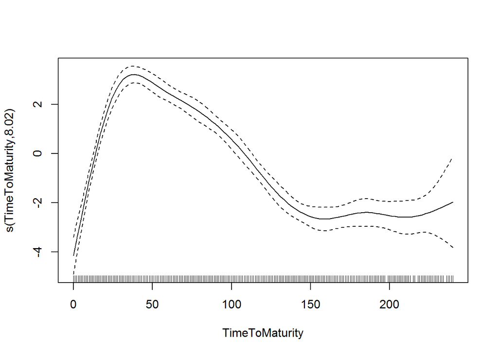

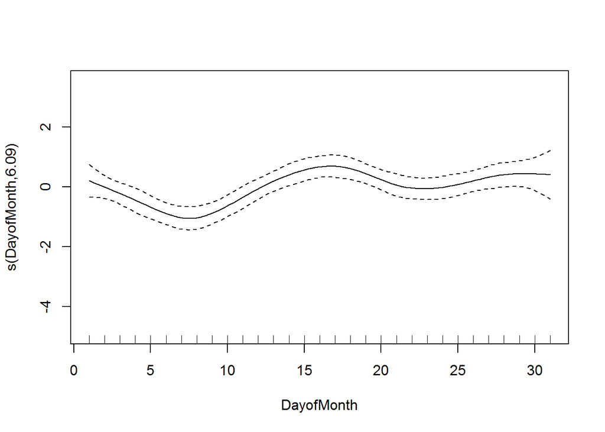

```r
plot(model1)
```

```r
p <- predict(model1, type="lpmatrix")
```

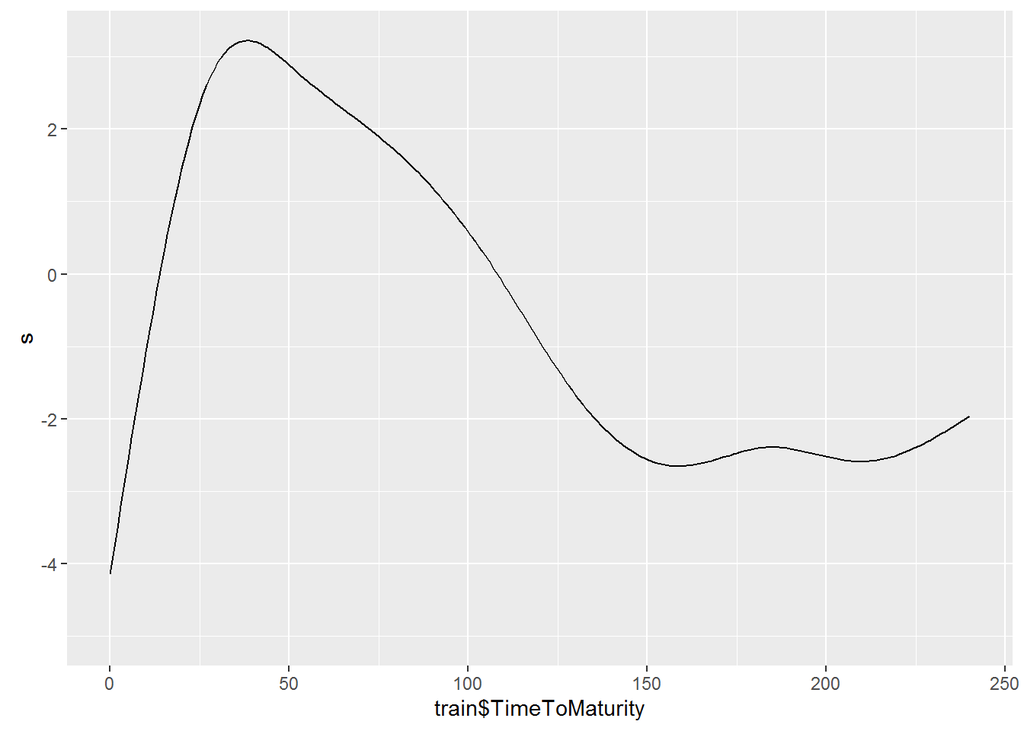

```r
beta <- coef(model1)[grepl("TimeToMaturity", names(coef(model1)))]
s <- p[,grepl("TimeToMaturity", colnames(p))] %*% beta
ggplot(data=cbind.data.frame(s, train$TimeToMaturity), aes(x=train$TimeToMaturity, y=s, ymin = -5, ymax = 3)) + geom_line()
```

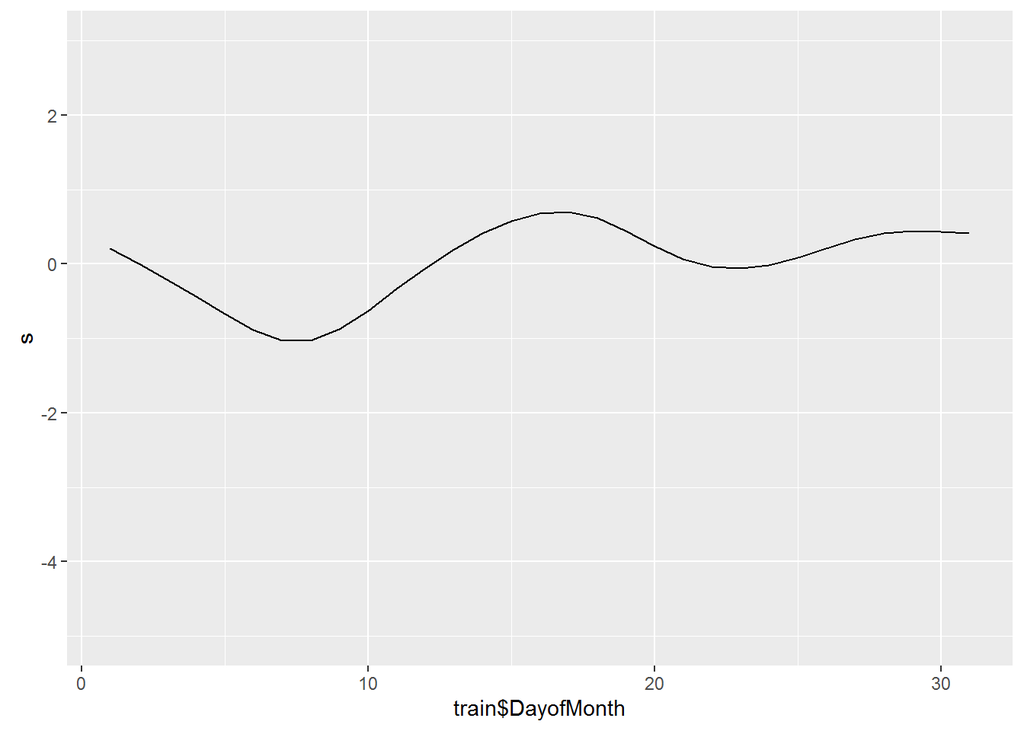

```r
beta <- coef(model1)[grepl("DayofMonth", names(coef(model1)))]
s <- p[,grepl("DayofMonth", colnames(p))] %*% beta
ggplot(data=cbind.data.frame(s, train$DayofMonth), aes(x=train$DayofMonth, y=s, ymin = -5, ymax = 3)) + geom_line()
```

```r
model1$coefficients
```

```
##               (Intercept)                       Day
##             10.3018663006             -0.0001832497
##   factor(ProductType)Bond factor(ProductType)Energy
##              1.8795981985              0.8613561472
##     factor(ProductType)FX  factor(ProductType)Index
##              0.3924724966              1.0011930275
##  factor(ProductType)Metal     factor(ProductName)CL
##             -0.8856536139              1.4276930053
##     factor(ProductName)ES     factor(ProductName)GC
##              2.7296559547              0.0557389757
##     factor(ProductName)GE     factor(ProductName)HO
##              3.5929292016             -1.7426834585
##     factor(ProductName)KE     factor(ProductName)NG
##             -0.3839572591              0.2816459521
##     factor(ProductName)NQ     factor(ProductName)RB
##             -0.0991368305             -0.8479828102
##     factor(ProductName)SI     factor(ProductName)UB
##             -0.9413925896             -0.2087464159
##     factor(ProductName)YM     factor(ProductName)ZB
##             -1.6293260967             -0.3566482873
##     factor(ProductName)ZC     factor(ProductName)ZF
##              4.6252942638              1.7168914726
##     factor(ProductName)ZL     factor(ProductName)ZM
##             -0.0073933742              0.5816414999
##     factor(ProductName)ZN     factor(ProductName)ZQ
##              1.8153898667             -0.4072405312
##     factor(ProductName)ZT     factor(ProductName)ZW
##              1.0626355521              2.2373149143
##   factor(DayOfTheWeek)Mon   factor(DayOfTheWeek)Thu
##              0.1295957812             -0.0945932061
##   factor(DayOfTheWeek)Tue   factor(DayOfTheWeek)Wed
##              0.2141311072              0.2975142385
##       s(TimeToMaturity).1       s(TimeToMaturity).2
##              4.0862305550              4.3135379923
##       s(TimeToMaturity).3       s(TimeToMaturity).4
##              3.1630997939              1.5023437313
##       s(TimeToMaturity).5       s(TimeToMaturity).6
##             -0.4519558507             -1.5735693297
##       s(TimeToMaturity).7       s(TimeToMaturity).8
##             -1.7185577599             -2.0030828934
##       s(TimeToMaturity).9           s(DayofMonth).1
##             -1.8649636379             -0.5771224168
##           s(DayofMonth).2           s(DayofMonth).3
##             -1.0950315981             -0.3982820876
##           s(DayofMonth).4           s(DayofMonth).5
##              0.4158307409              0.6008246973
##           s(DayofMonth).6           s(DayofMonth).7
##              0.0066697253             -0.0404617009
##           s(DayofMonth).8           s(DayofMonth).9
##              0.3318092433              0.3996305470
```

```r
model1$sp #spline parameters
```

```
## s(TimeToMaturity)1 s(TimeToMaturity)2     s(DayofMonth)1
##          0.1832887          2.0920446          1.4150780
##     s(DayofMonth)2
##         19.9633161
```

Unsurprisingly, the below residuals are quite large, especially since they are for the box cox transformed trade counts. However they seem constant so an assumption of the linear regression model is fufilled.

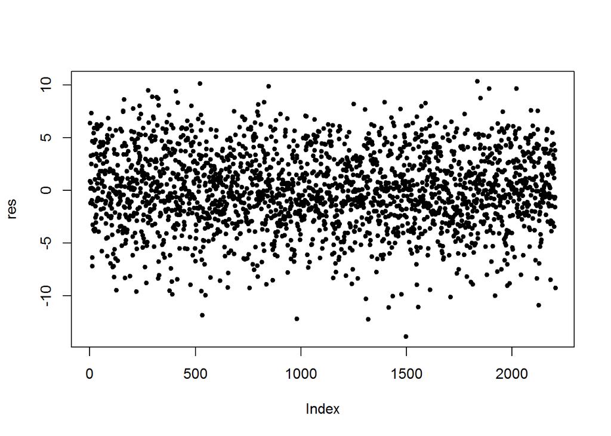

```r
res=model1$residuals
plot(res, pch=20)
```

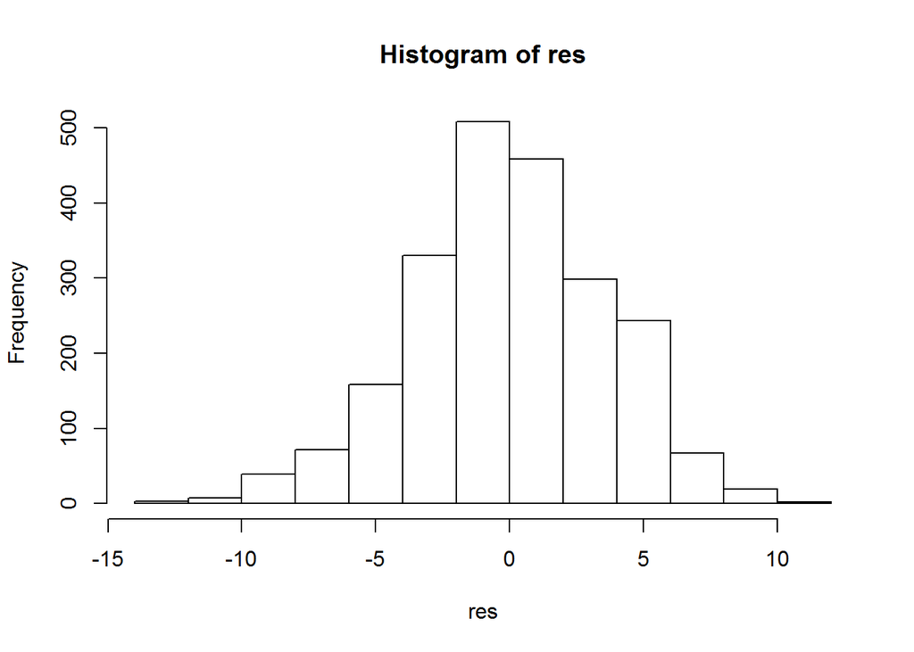

```r
hist(res)
```

Actual values are black, predicted values are red

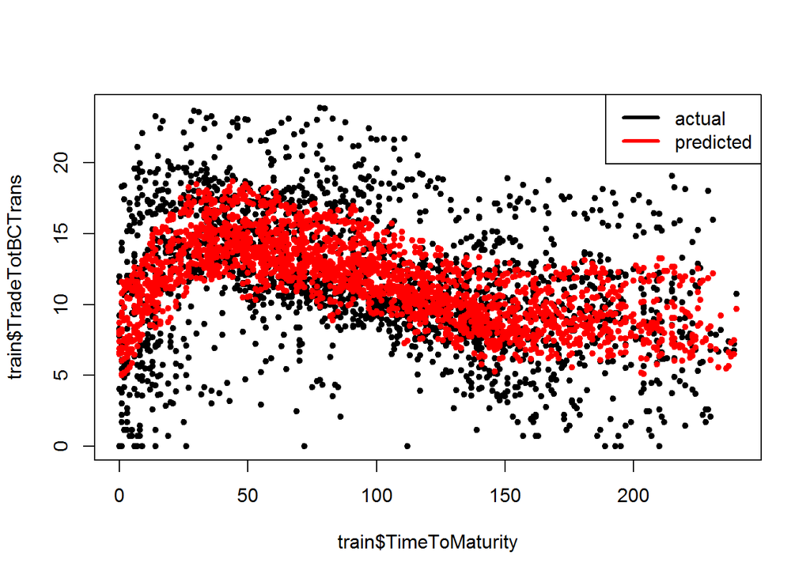

```r
trainPred=model1$fitted.values
plot(train$TimeToMaturity, train$TradeTotBCTrans, pch=20, ylim=c(min(train$TradeTotBCTrans, trainPred), max(train$TradeTotBCTrans, trainPred)))
points(train$TimeToMaturity, trainPred, col="red", pch=20)
legend("topright", c("actual", "predicted"),lwd=c(3,3),col=c("black", "red"))
```

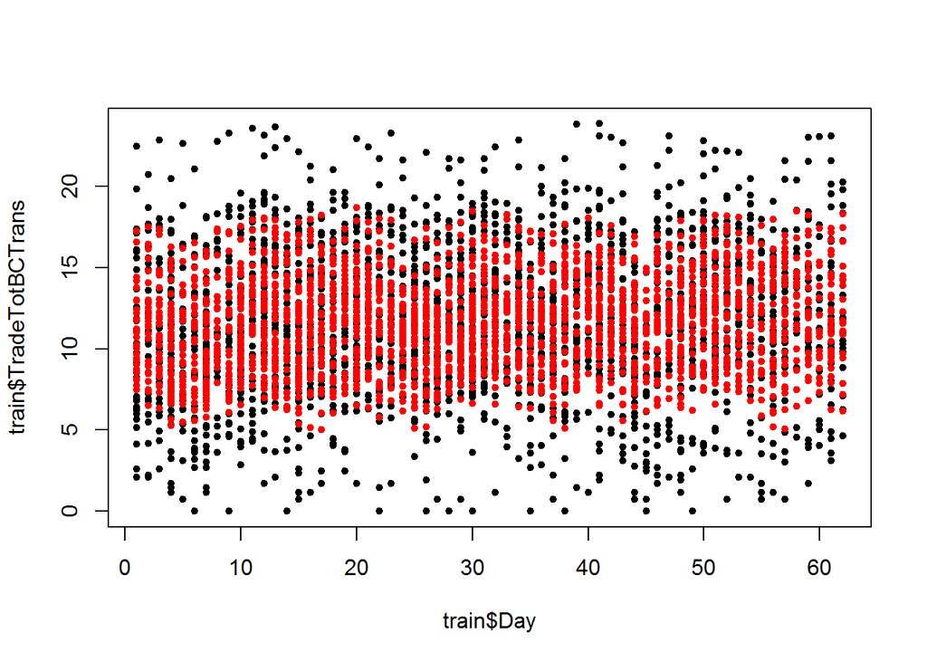

```r
plot(train$Day, train$TradeTotBCTrans, pch=20, ylim=c(min(train$TradeTotBCTrans, trainPred), max(train$TradeTotBCTrans, trainPred)))
points(train$Day, trainPred, col="red", pch=20)
```

Nice thing about this model is that its performance remains just as bad on the test data. The point being that at least it does not perform worse on new data.

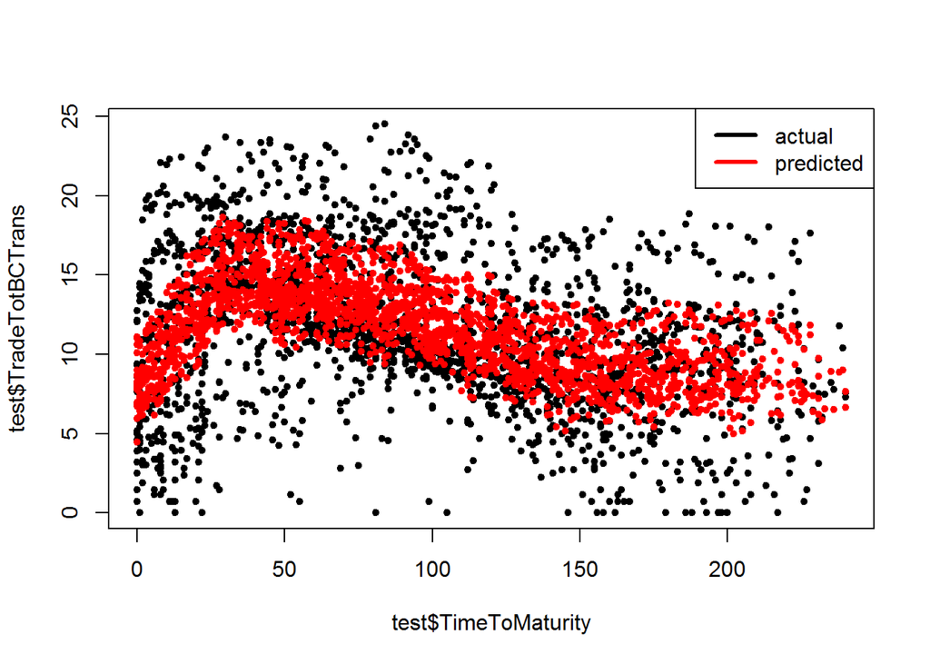

```r
testPred <- predict(model1, test)

plot(test$TimeToMaturity, test$TradeTotBCTrans, pch=20, ylim=c(min(test$TradeTotBCTrans, testPred), max(test$TradeTotBCTrans, testPred)))
points(test$TimeToMaturity, testPred, col="red", pch=20)
legend("topright", c("actual", "predicted"),lwd=c(3,3),col=c("black", "red"))
```

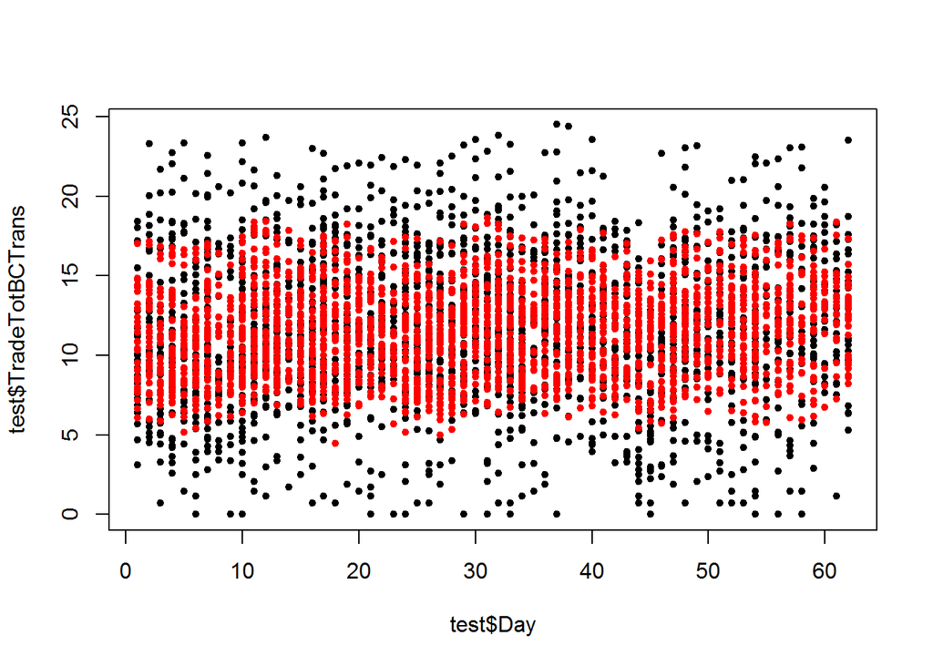

```r
plot(test$Day, test$TradeTotBCTrans, pch=20, ylim=c(min(test$TradeTotBCTrans, testPred), max(test$TradeTotBCTrans, testPred)))
points(test$Day, testPred, col="red", pch=20)
```

Model was only trained on 1/4 of data so only testing on 1/4 of future data.

```r
new_data=trade_data[(n+1):dim(trade_data)[1], ]
set.seed(1-10-17)
newdata_id=sample(1:n, n)[1:floor(n/2)]
new_data1=new_data[newdata_id, ]
head(new_data1)
```

```
##      ProductName   Maturity       Date TimeToMaturity DayOfTheWeek
## 7552          ZN 2016-12-20 2016-09-14             97          Wed
## 2184          GE 2016-12-19 2016-09-21             89          Wed
## 8436          ZT 2016-12-30 2016-08-08            144          Mon
## 3970          NQ 2016-09-16 2016-08-19             28          Fri
## 5203          SI 2017-01-27 2016-10-07            112          Fri
## 6859          ZL 2016-12-14 2016-11-08             36          Tue
##      DayofMonth ProductType Day DayTradeTotal TradeTotBCTrans
## 7552         14        Bond  92        744160      21.3589021
## 2184         21          FX  97        328774      19.4883910
## 8436          8        Bond  66             2       0.7085481
## 3970         19       Index  75        176731      18.1301803
## 5203          7       Metal 109            42       4.2158577
## 6859          8         Agr 131         30637      14.5711523
##      TradeTotLogTrans
## 7552       13.5200113
## 2184       12.7031259
## 8436        0.6931472
## 3970       12.0823841
## 5203        3.7376696
## 6859       10.3299637
```

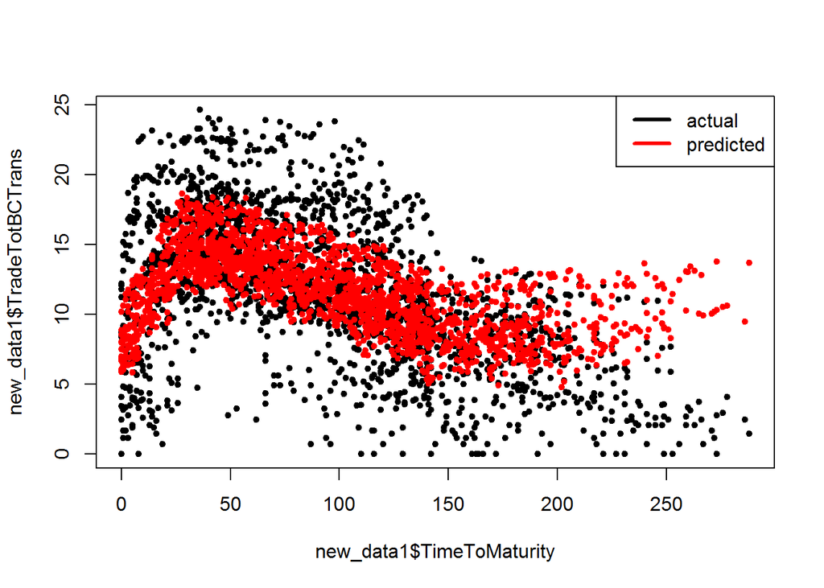

```r
new_data2=new_data[-newdata_id, ] #not used
new_data1Pred <- predict(model1, new_data1)
new_data1["Prediction"]=new_data1Pred
plot(new_data1$TimeToMaturity, new_data1$TradeTotBCTrans, pch=20, ylim=c(min(new_data1$TradeTotBCTrans, new_data1Pred), max(new_data1$TradeTotBCTrans, new_data1Pred)))
points(new_data1$TimeToMaturity, new_data1$Prediction, col="red", pch=20)
legend("topright", c("actual", "predicted"),lwd=c(3,3),col=c("black", "red"))
```

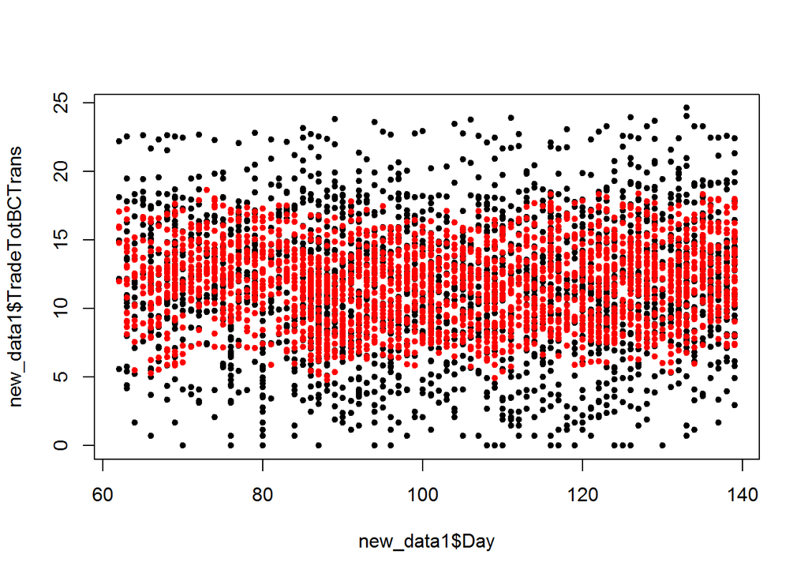

```r
plot(new_data1$Day, new_data1$TradeTotBCTrans, pch=20, ylim=c(min(new_data1$TradeTotBCTrans, new_data1Pred), max(new_data1$TradeTotBCTrans, new_data1Pred)))
points(new_data1$Day, new_data1$Prediction, col="red", pch=20)
```

```r
types=c('Metal', 'Bond', 'Agr', 'Energy', 'Index', 'FX')
MAEone_mod=c()
medians=c()
count=0
for (type in types){
  count=count+1
  typsub=subset(new_data1, ProductType==type)
  MAEone_mod[count]= mean(abs(typsub$TradeTotBCTrans-typsub$Prediction))
  medians[count]=median(typsub$TradeTotBCTrans)
}
```

Creating models for each product type.

```
## Metal
## Family: gaussian
## Link function: identity
##
## Formula:
## TradeTotBCTrans ~ s(TimeToMaturity, bs = "cr") + s(DayofMonth,
##     bs = "cr") + Day + factor(ProductName) + factor(DayOfTheWeek)
##
## Parametric coefficients:
##                         Estimate Std. Error t value Pr(>|t|)
## (Intercept)              7.78025    0.60295  12.904  < 2e-16 ***
## Day                      0.05067    0.01205   4.206 3.62e-05 ***
## factor(ProductName)SI   -0.56037    0.39425  -1.421    0.156
## factor(DayOfTheWeek)Mon -0.11374    0.65379  -0.174    0.862
## factor(DayOfTheWeek)Thu -0.04441    0.63939  -0.069    0.945
## factor(DayOfTheWeek)Tue  0.29850    0.62187   0.480    0.632
## factor(DayOfTheWeek)Wed  0.67780    0.62961   1.077    0.283
## ---
## Signif. codes:  0 '***' 0.001 '**' 0.01 '*' 0.05 '.' 0.1 ' ' 1
##
## Approximate significance of smooth terms:
##                      edf Ref.df      F p-value
## s(TimeToMaturity) 7.8156      9 32.938  <2e-16 ***
## s(DayofMonth)     0.5159      3  0.368   0.143
## ---
## Signif. codes:  0 '***' 0.001 '**' 0.01 '*' 0.05 '.' 0.1 ' ' 1
##
## R-sq.(adj) =  0.537   Deviance explained = 56.2%
## GCV = 10.604  Scale est. = 9.9972    n = 268
```

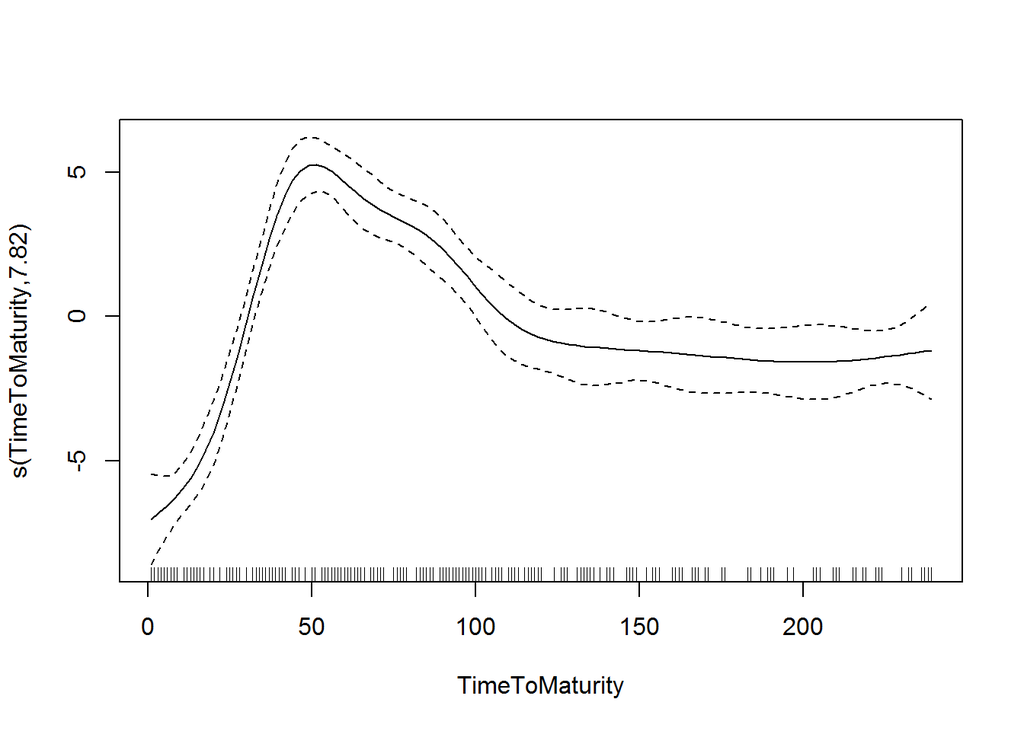

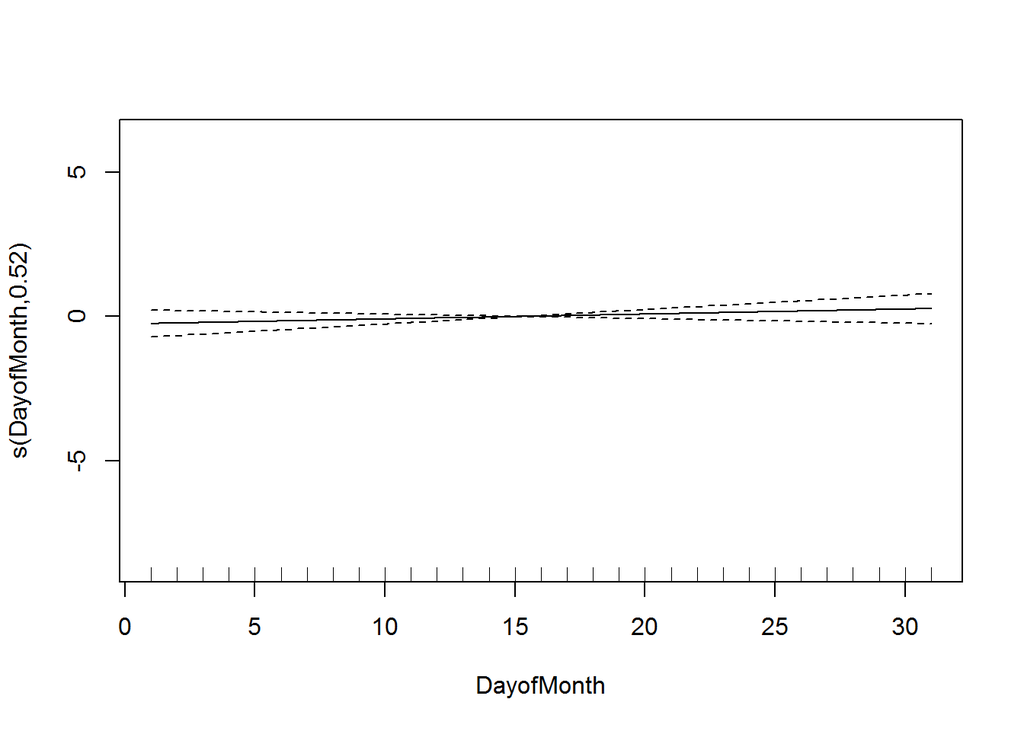

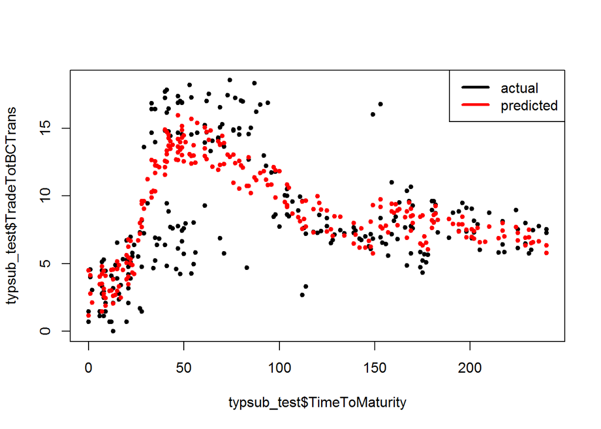

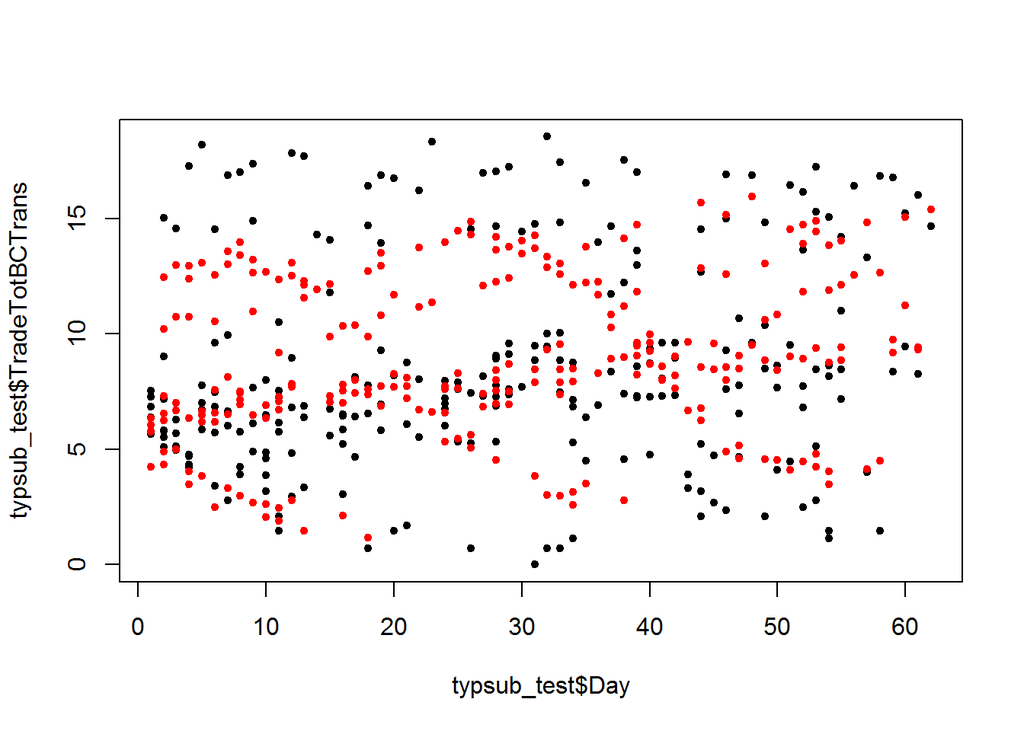

```
## Metal
```

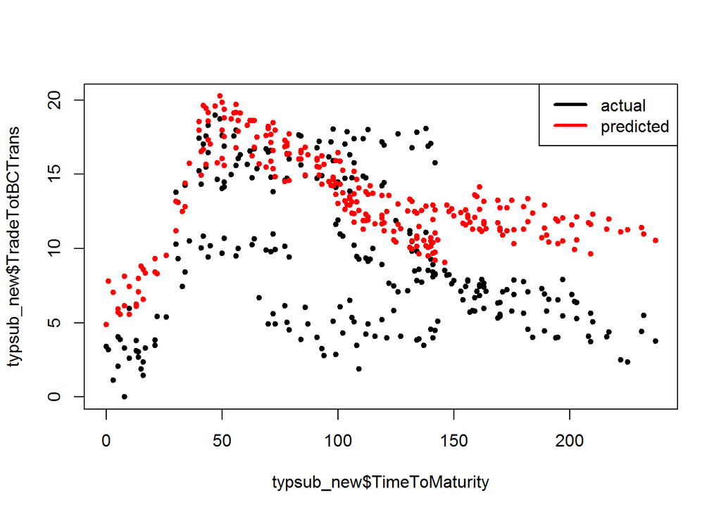

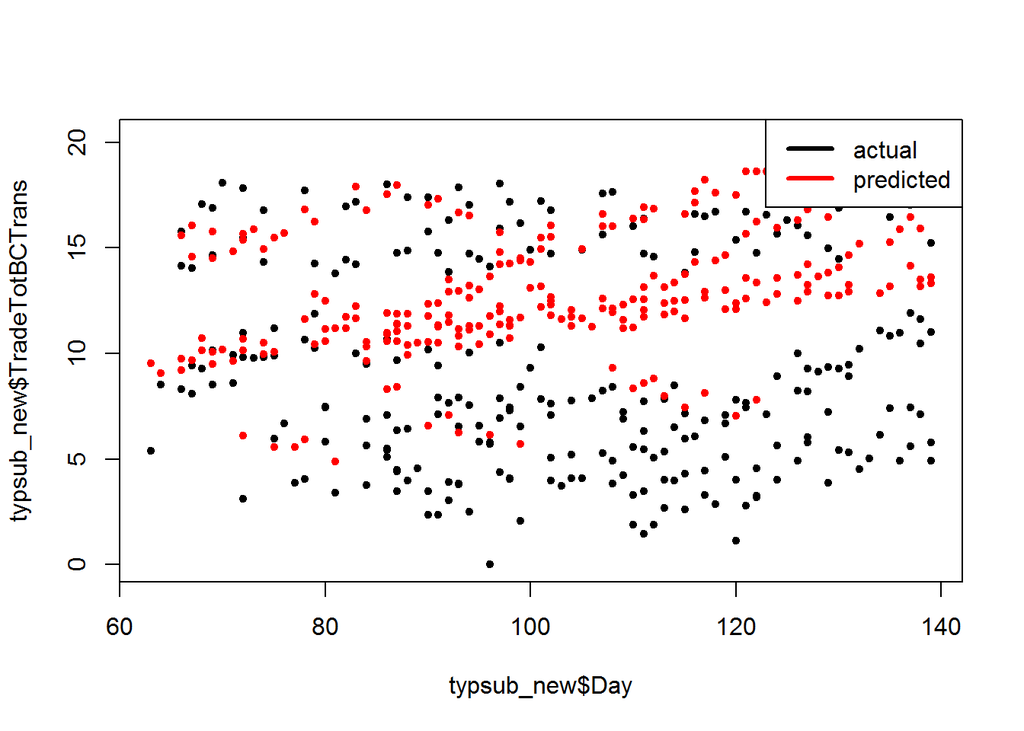

```
##        ProductName   Maturity       Date TimeToMaturity DayOfTheWeek
## 5203            SI 2017-01-27 2016-10-07            112          Fri
## 5203.1          SI 2017-01-27 2016-10-07            112          Fri
## 5203.2          SI 2017-01-27 2016-10-07            112          Fri
## 5203.3          SI 2017-01-27 2016-10-07            112          Fri
## 5203.4          SI 2017-01-27 2016-10-07            112          Fri
## 5203.5          SI 2017-01-27 2016-10-07            112          Fri
##        DayofMonth ProductType Day DayTradeTotal TradeTotBCTrans
## 5203            7       Metal  32            42        4.215858
## 5203.1          7       Metal  49            42        4.215858
## 5203.2          7       Metal  86            42        4.215858
## 5203.3          7       Metal  22            42        4.215858
## 5203.4          7       Metal  32            42        4.215858
## 5203.5          7       Metal  45            42        4.215858
##        TradeTotLogTrans Prediction
## 5203            3.73767   12.31113
## 5203.1          3.73767   12.31113
## 5203.2          3.73767   12.31113
## 5203.3          3.73767   12.31113
## 5203.4          3.73767   12.31113
## 5203.5          3.73767   12.31113
```

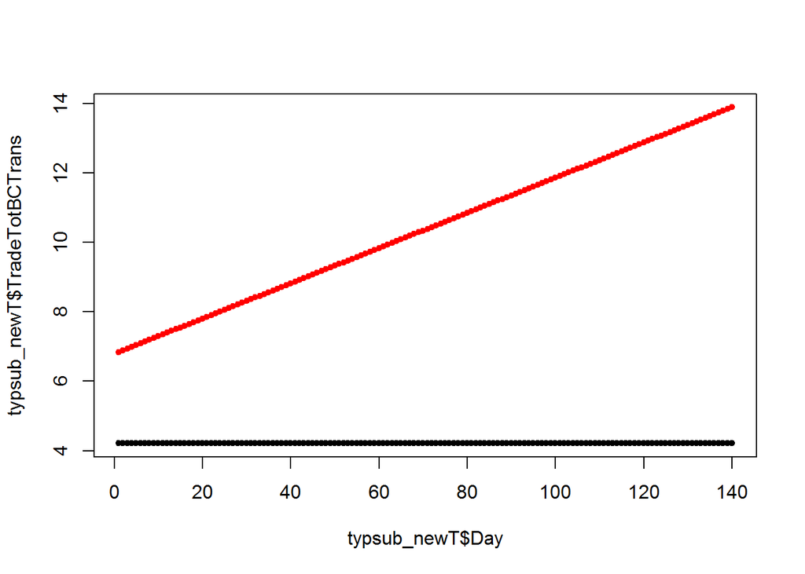

```
## True Day: 109
##
## Bond
## Family: gaussian
## Link function: identity
##
## Formula:
## TradeTotBCTrans ~ s(TimeToMaturity, bs = "cr") + s(DayofMonth,
##     bs = "cr") + Day + factor(ProductName) + factor(DayOfTheWeek)
##
## Parametric coefficients:
##                          Estimate Std. Error t value Pr(>|t|)
## (Intercept)             11.446139   0.529218  21.628  < 2e-16 ***
## Day                     -0.024620   0.009551  -2.578  0.01020 *
## factor(ProductName)UB    0.855964   0.633639   1.351  0.17730
## factor(ProductName)ZB    1.441119   0.551699   2.612  0.00925 **
## factor(ProductName)ZF    3.247079   0.599878   5.413 9.30e-08 ***
## factor(ProductName)ZN    3.715932   0.584110   6.362 4.22e-10 ***
## factor(ProductName)ZQ    1.118916   0.400149   2.796  0.00535 **
## factor(ProductName)ZT    2.401504   0.586158   4.097 4.82e-05 ***
## factor(DayOfTheWeek)Mon  0.251005   0.495187   0.507  0.61244
## factor(DayOfTheWeek)Thu -0.158570   0.502185  -0.316  0.75230
## factor(DayOfTheWeek)Tue  0.027214   0.485500   0.056  0.95532
## factor(DayOfTheWeek)Wed  0.276652   0.485478   0.570  0.56901
## ---
## Signif. codes:  0 '***' 0.001 '**' 0.01 '*' 0.05 '.' 0.1 ' ' 1
##
## Approximate significance of smooth terms:
##                     edf Ref.df      F p-value
## s(TimeToMaturity) 6.565      9 47.203 < 2e-16 ***
## s(DayofMonth)     4.176      9  1.741 0.00165 **
## ---
## Signif. codes:  0 '***' 0.001 '**' 0.01 '*' 0.05 '.' 0.1 ' ' 1
##
## R-sq.(adj) =  0.485   Deviance explained = 50.5%
## GCV = 12.793  Scale est. = 12.281    n = 569
```

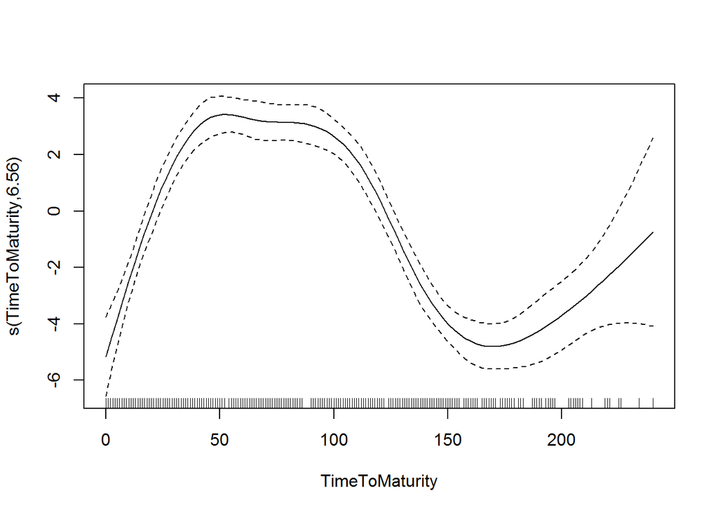

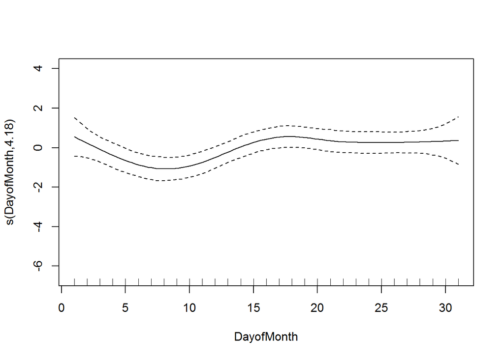

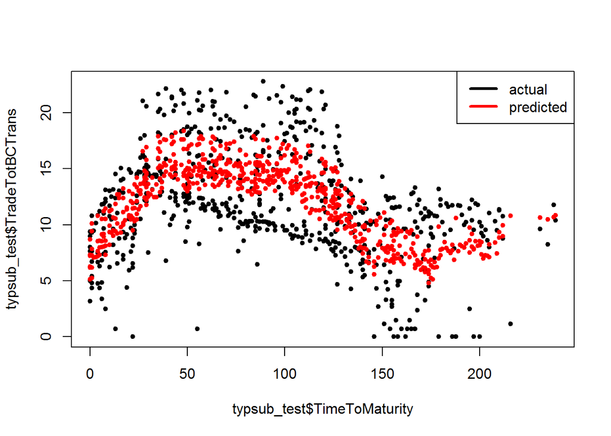

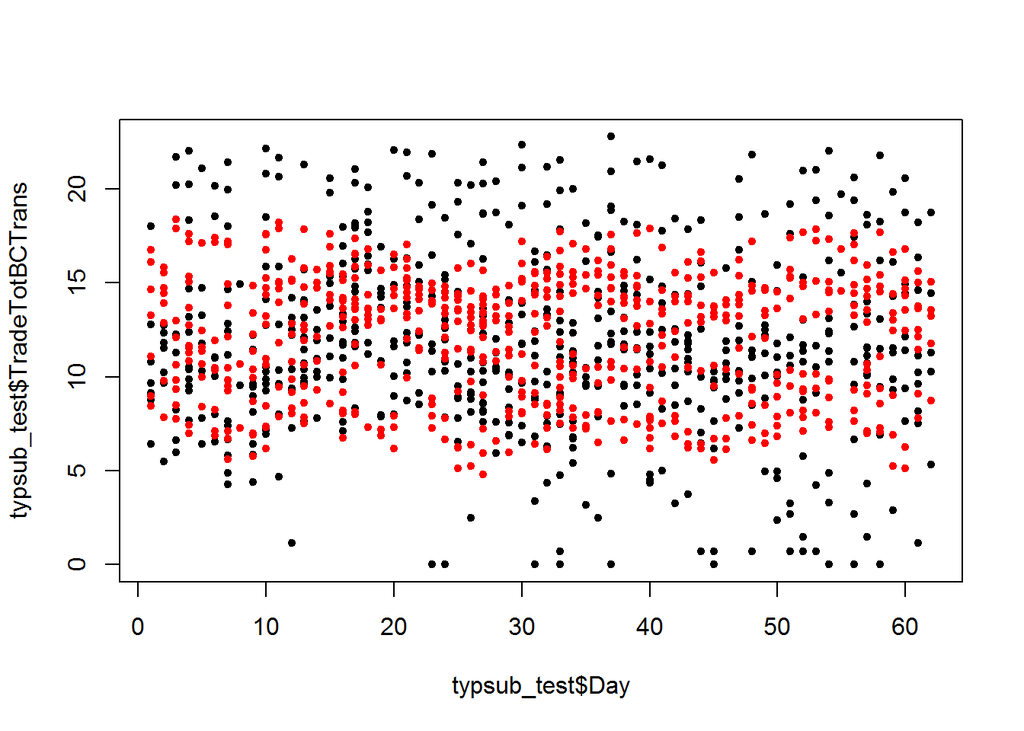

```
## Bond
```

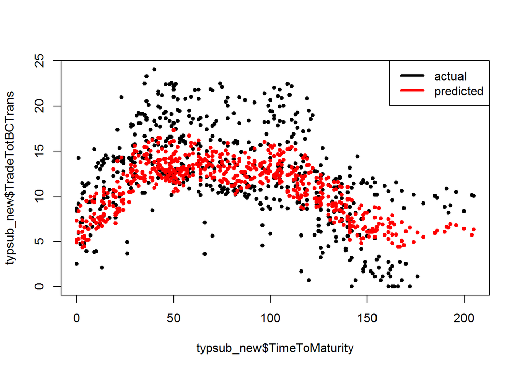

[30 more figures not shown]

```
## True Day: 97
##
```

```r
MAEmult_mod=c()
all_products=c()
all_medians=c()
all_MAE=c()
count=0
for (type in types){
  count=count+1
  typsub=subset(train, ProductType==type)
  model <- gam(TradeTotBCTrans ~ s(TimeToMaturity, bs="cr") + s(DayofMonth, bs="cr") + Day + factor(ProductName) + factor(DayOfTheWeek), family=gaussian(), data = typsub, method="GCV.Cp", select=TRUE)

  typsub_test=subset(test, ProductType==type)
  testPred <- predict(model, typsub_test)
  cat(type)
  print(summary(model))
  plot(model)
  typsub_test["Prediction"]=testPred
  plot(typsub_test$TimeToMaturity, typsub_test$TradeTotBCTrans, pch=20, ylim=c(min(typsub_test$TradeTotBCTrans, typsub_test$Prediction), max(typsub_test$TradeTotBCTrans, typsub_test$Prediction)))
  points(typsub_test$TimeToMaturity, typsub_test$Prediction, col="red", pch=20)
  legend("topright", c("actual", "predicted"),lwd=c(3,3),col=c("black", "red"))
  plot(typsub_test$Day, typsub_test$TradeTotBCTrans, pch=20, ylim=c(min(typsub_test$TradeTotBCTrans, typsub_test$Prediction), max(typsub_test$TradeTotBCTrans, typsub_test$Prediction)))
  points(typsub_test$Day, typsub_test$Prediction, col="red", pch=20)

  typsub_new=subset(new_data1, ProductType==type)
  new_data1Pred <- predict(model, typsub_new)
  typsub_new["Prediction"]=new_data1Pred
  cat(type)
  plot(typsub_new$TimeToMaturity, typsub_new$TradeTotBCTrans, pch=20, ylim=c(min(typsub_new$TradeTotBCTrans, typsub_new$Prediction), max(typsub_new$TradeTotBCTrans, typsub_new$Prediction)))
  points(typsub_new$TimeToMaturity, typsub_new$Prediction, col="red", pch=20)
  legend("topright", c("actual", "predicted"),lwd=c(3,3),col=c("black", "red"))
  plot(typsub_new$Day, typsub_new$TradeTotBCTrans, pch=20, ylim=c(min(typsub_new$TradeTotBCTrans, typsub_new$Prediction), max(typsub_new$TradeTotBCTrans, typsub_new$Prediction)))
  points(typsub_new$Day, typsub_new$Prediction, col="red", pch=20)
  MAEmult_mod[count]= mean(abs(typsub_new$TradeTotBCTrans-typsub_new$Prediction))

  typsub_newT=typsub_new[rep(1,2200),]
  true=typsub_newT$Day
  set.seed(1-13-17)
  typsub_newT['Day']=sample(rep(1:140, 16)[1:2200], 2200)
  print(head(typsub_newT))
  new_data1PredT <- predict(model, typsub_newT)
  typsub_newT["Prediction"]=new_data1PredT
  legend("topright", c("actual", "predicted"),lwd=c(3,3),col=c("black", "red"))
  plot(typsub_newT$Day, typsub_newT$TradeTotBCTrans, pch=20, ylim=c(min(typsub_newT$TradeTotBCTrans, typsub_newT$Prediction), max(typsub_newT$TradeTotBCTrans, typsub_newT$Prediction)))
  points(typsub_newT$Day, typsub_newT$Prediction, col="red", pch=20)
  cat("True Day:", true[1], "\n", "\n")

  MAEmult_modP=c()
  medianP=c()
  countP=0
  products=as.vector(unique(typsub_new$ProductName))
  all_products=append(all_products,products,length(all_products))
  for (product in products){
      countP=countP+1
      prodsub=subset(typsub_new, ProductName==product)
      MAEmult_modP[countP]= mean(abs(prodsub$TradeTotBCTrans-prodsub$Prediction))
      medianP[countP]=median(prodsub$TradeTotBCTrans)
  }
  all_MAE=append(all_MAE,MAEmult_modP,length(all_MAE))
  all_medians=append(all_medians, medianP, length(all_medians))
}
```

```r
data.frame(types, MAEmult_mod, MAEone_mod, median=medians) #separate models for each product type
```

```
##    types MAEmult_mod MAEone_mod    median
## 1  Metal    4.834429   3.539754  7.988823
## 2   Bond    3.222449   3.065541 12.190952
## 3    Agr    2.405032   1.782073 11.668960
## 4 Energy    1.571237   1.987582 11.869997
## 5  Index    1.912505   5.489929  9.882891
## 6     FX    5.511455   4.090837 13.073397
```

```r
data.frame(all_products, MAE=all_MAE, median=all_medians) #separate models
```

```
##    all_products      MAE    median
## 1            SI 4.795351  7.356573
## 2            GC 4.867276  9.198008
## 3            ZN 4.533263 17.162165
## 4            ZT 3.780942 15.321273
## 5            ZF 4.345030 17.732469
## 6            ZB 3.803675 12.357477
## 7            HO 2.507110 11.082707
## 8            ZQ 2.437350 11.967761
## 9            UB 3.418256 15.628825
## 10           ZL 2.470744 11.079648
## 11           ZM 2.566281 11.010611
## 12           ZC 2.315551 14.200150
## 13           KE 2.324298  9.829555
## 14           ZW 2.284337 13.247225
## 15           CL 1.709770 13.838677
## 16           RB 1.642282 11.100576
## 17           NG 1.419711 11.554323
## 18           NQ 1.903774  7.914951
## 19           ES 2.157625  9.779657
## 20           YM 1.540348 16.700766
## 21           GE 5.565276 14.052336
## 22           6E 5.463439  8.555509
```